# Lung cancer patients

# Data Mining Project - Group 6

## 1- Problem:

In this Data Mining project, we chose “Lung Cancer Prediction” dataset. Our goal of collecting this dataset was to analyze it and study the main reasons of lung cancer and how to treat it. We need to analyze the dataset and find the key risk factors associated with the disease. To achieve this, we will emply various data mining techniques including data preprocessing, data analysis, classification methods, and clustering. Our dataset contains information on patients with lung cancer, including their age, gender, air pollution exposure, alcohol use, dust allergy, occupational hazards, genetic risk, chronic lung disease, balanced diet, obesity, smoking, passive smoker, chest pain, coughing of blood, fatigue, weight loss, shortness of breath, wheezing, swallowing difficulty, clubbing of finger nails and snoring, we have 1000 observations to analyze.

## 2- Data Mining Task:

We need to study the relationships between the attributes and their affect towards the patient’s level of lung cancer.

We will use **classification** based on the class label “Level”, it has three values: Low, Medium, High. We will also use **clustering** to group similar data values together.

## 3- Data:

#### Source:

Kaggle: https://www.kaggle.com/datasets/thedevastator/cancer-patients-and-air-pollution-a-new-link?resource=download

#### Number of Attributes:

26

#### Number of Observations:

1000

#### Class label: Level

#### Attribute characteristics:

| Attribute name | Description | Data type |
| --- | --- | --- |
| Age | The age of the patient. | Numeric |
| Gender | The gender of the patient. | Ordinal |
| Air Pollution | The level of air pollution exposure of the patient. | Ordinal |
| Alcohol use | The level of alcohol use of the patient. | Ordinal |
| Dust Allergy | The level of dust allergy of the patient. | Ordinal |
| OccuPational Hazards | The level of occupational hazards of the patient. | Ordinal |
| Genetic Risk | The level of genetic risk of the patient. | Ordinal |
| Chronic Lung Disease | The level of chronic lung disease of the patient. | Ordinal |
| Balanced Diet | The level of balanced diet of the patient. | Ordinal |
| Obesity | The level of obesity of the patient. | Ordinal |
| Smoking | The level of smoking of the patient. | Ordinal |
| Passive Smoker | The level of passive smoker of the patient. | Ordinal |
| Chest Pain | The level of chest pain of the patient. | Ordinal |
| Coughing of Blood | The level of coughing of blood of the patient. | Ordinal |
| Fatigue | The level of fatigue of the patient. | Ordinal |
| Weight Loss | The level of weight loss of the patient. | Ordinal |
| Shortness of Breath | The level of shortness of breath of the patient. | Ordinal |
| Wheezing | The level of wheezing of the patient. | Ordinal |
| Swallowing Difficulty | The level of swallowing difficulty of the patient. | Ordinal |
| Clubbing of Finger Nails | The level of clubbing of finger nails of the patient. | Ordinal |

#### Missing values:

```r
is.na(data)
### The dataset has no missing values.
```

There are no missing values.

#### Statistical Measures:

```r
summary(data)
### calculating the min, 1st quartile, Median, mean, 3rd quartile, and the max of the age attribute.
```

#### Outliers:

We detected outliers in almost all of our attributes (Excluding “Patient Id” and “Level” attributes).

| Attribute | Number or outliers |
| --- | --- |
| Age | 10 |
| Air Pollution | 19 |
| Alcohol use | 169 |
| Dust Allergy | 60 |
| OcuuPAtional Hazards | 30 |
| Genetic Risk | 40 |
| Chronic Lung Disease | 10 |
| Balanced Diet | 10 |
| Obesity | 20 |
| Smoking | 148 |
| Passive Smoking | 29 |
| Chest Pain | 30 |
| Coughing of Blood | 70 |
| Fatigue | 50 |
| Weight Loss | 51 |
| Shortness of Breath | 40 |
| Wheezing | 10 |
| Swallowing Difficulty | 41 |
| Clubbing of Finger Nails | 10 |
| Frequent Cold | 10 |
| Dry Cough | 21 |
| Snoring | 31 |

```r
library(outliers)

OutAge = outlier(data$Age, logical = TRUE)
sum(OutAge)
### Smoothing outliers when present.

### Repeat process to smooth all outliers in the dataset.
```

```r
OutAirP = outlier(data$Air.Pollution, logical = TRUE)
sum(OutAirP)

OutAlcohol = outlier(data$Alcohol.use, logical = TRUE)
sum(OutAlcohol)

OutDust = outlier(data$Dust.Allergy, logical = TRUE)
sum(OutDust)

OutOccu = outlier(data$OccuPational.Hazards, logical = TRUE)
sum(OutOccu)

OutGenetic = outlier(data$Genetic.Risk, logical = TRUE)
sum(OutGenetic)

OutChroncDisease = outlier(data$chronic.Lung.Disease, logical = TRUE)
sum(OutChroncDisease)

OutDiet = outlier(data$Balanced.Diet, logical = TRUE)
sum(OutDiet)

OutObesity = outlier(data$Obesity, logical = TRUE)
sum(OutObesity)

OutSmoking = outlier(data$Smoking, logical = TRUE)
sum(OutSmoking)

OutPassiveS= outlier(data$Passive.Smoker, logical = TRUE)
sum(OutPassiveS)

OutChestPain = outlier(data$Chest.Pain, logical = TRUE)
sum(OutChestPain)

OutBloodCoughing = outlier(data$Coughing.of.Blood, logical = TRUE)
sum(OutBloodCoughing)

OutFatigue = outlier(data$Fatigue, logical = TRUE)
sum(OutFatigue)

OutWeightLoss = outlier(data$Weight.Loss, logical = TRUE)
sum(OutWeightLoss)

OutBreathShortness = outlier(data$Shortness.of.Breath, logical = TRUE)
sum(OutBreathShortness)

OutWheezing = outlier(data$Wheezing, logical = TRUE)
sum(OutWheezing)

OutSwallow = outlier(data$Swallowing.Difficulty, logical = TRUE)
sum(OutSwallow)

OutClubbing = outlier(data$Clubbing.of.Finger.Nails, logical = TRUE)
sum(OutClubbing)

OutCold = outlier(data$Frequent.Cold, logical = TRUE)
sum(OutCold)

OutDryCough = outlier(data$Dry.Cough, logical = TRUE)
sum(OutDryCough)

OutSnoring = outlier(data$Snoring, logical = TRUE)
sum(OutSnoring)
```

#### Plotting Methods:

Graphs

Discription

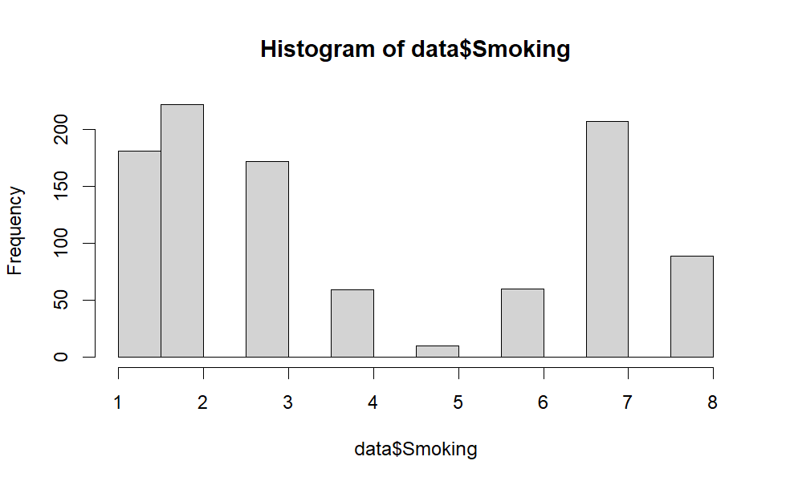

The Histogram shows the level frequency of Smoking in patients.

We noticed that the highest frequency was when the level of smoking of the patient is within the range [1-3] and [7] and it illustrates there is a lot of outliers in the dataset.

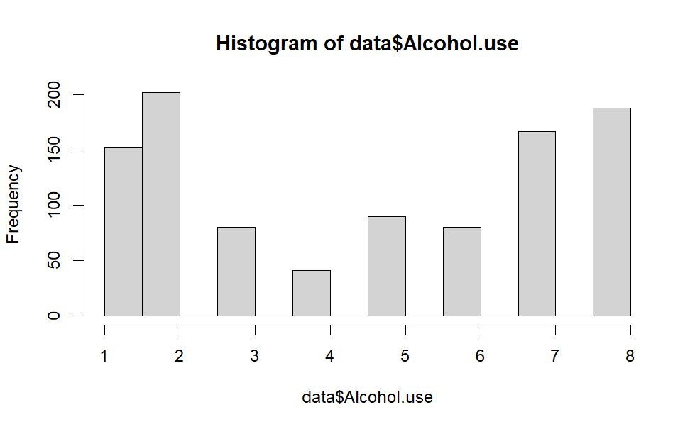

The Histogram shows the level frequency of alcohol use in patients.

We noticed that the highest frequency was when the level Alcohol use within this range [1-2] and [7-8].

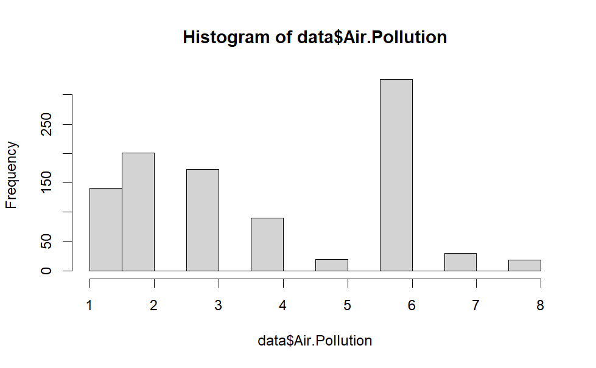

The Histogram shows the level frequency of Air pollution in patients.

We noticed that the highest frequency was when the level Air pollution in the 6 and it illustrates there is a lot of outliers in the dataset.

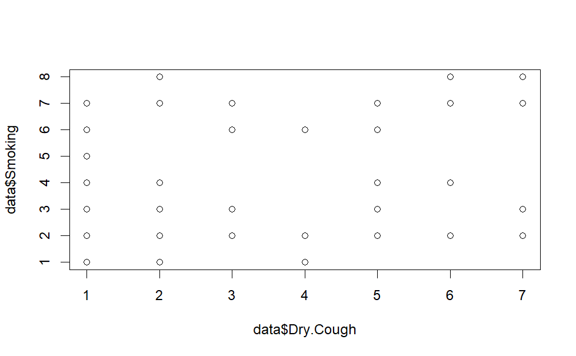

The scatter plot shows that there is no relation between Dry cough and Smoking.

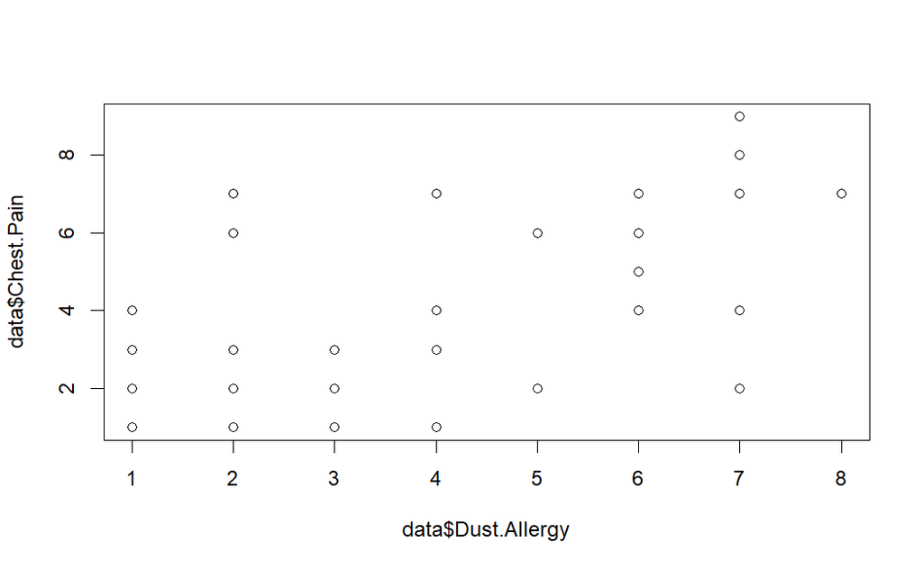

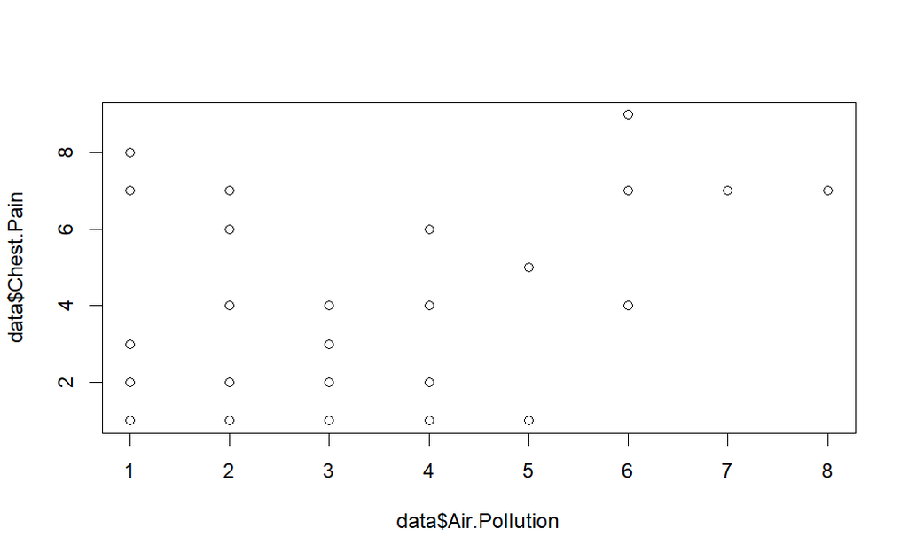

The scatter plot shows that there is no relation between Air pollution and Chest pain.

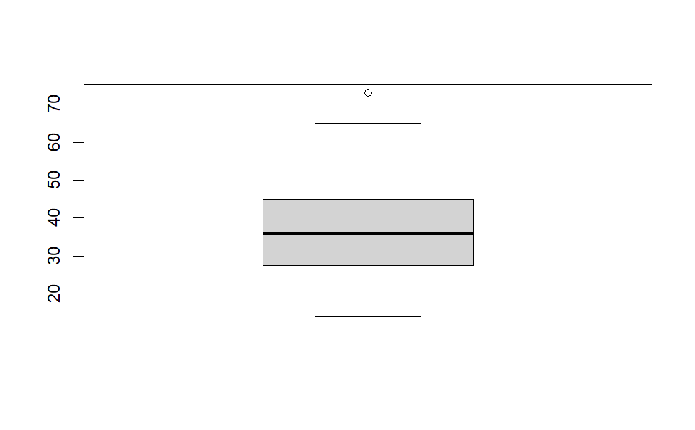

The age boxplot shows that the average age of the patients lies between 30 and 40 years, in addition to an outlier in age attribute.

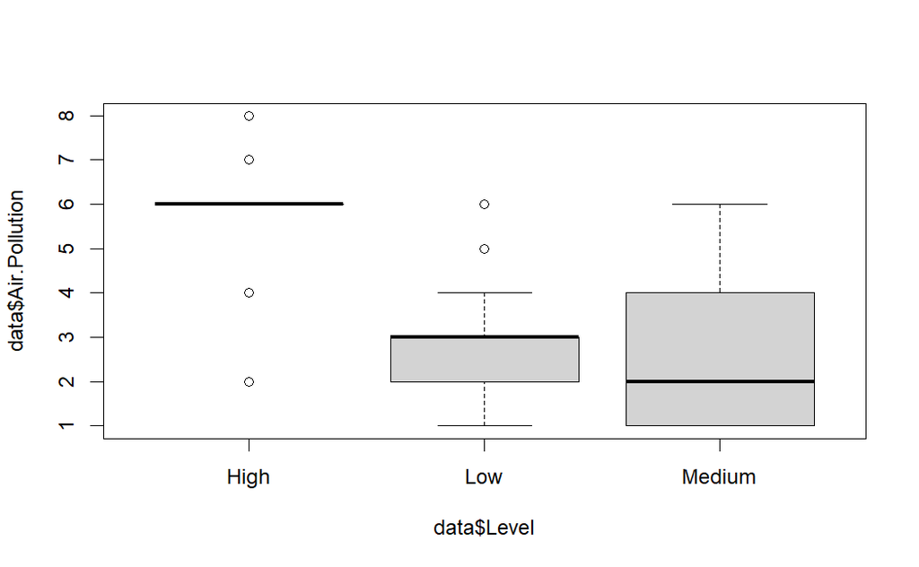

The boxplot show there is outliers and Most of the values fall in the medium range and there is no relation between increasing the level of Air pollution and increasing level of lung cancer.

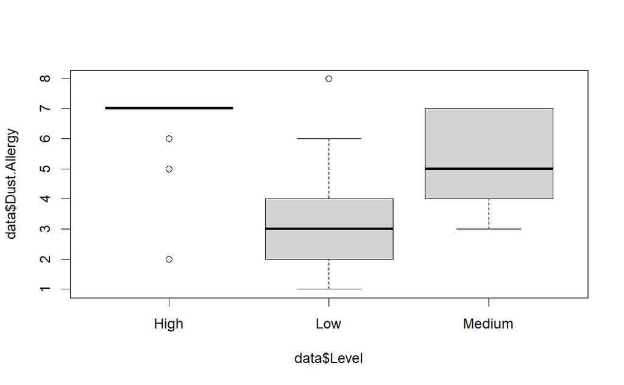

The boxplot show there is outliers and Most of the values fall in the medium range and there is a relation between increasing the level Dust Allergy and increasing level lung cancer.

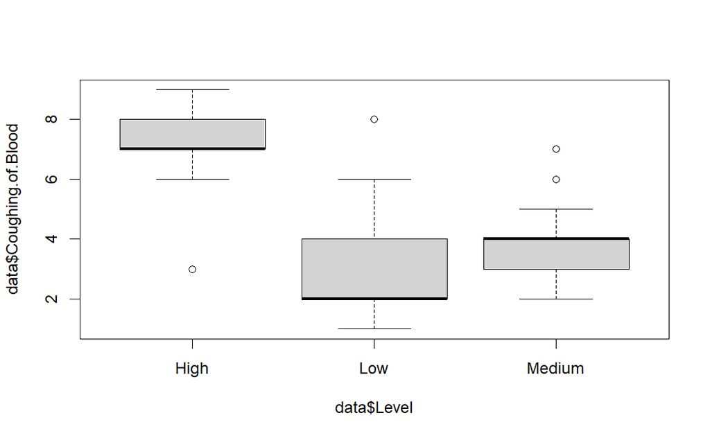

The boxplot shows that most of the values fall in the low range and there is a relation between increasing the level coughing of blood and increasing level lung cancer, there is outliers too which needs to be smoothed.

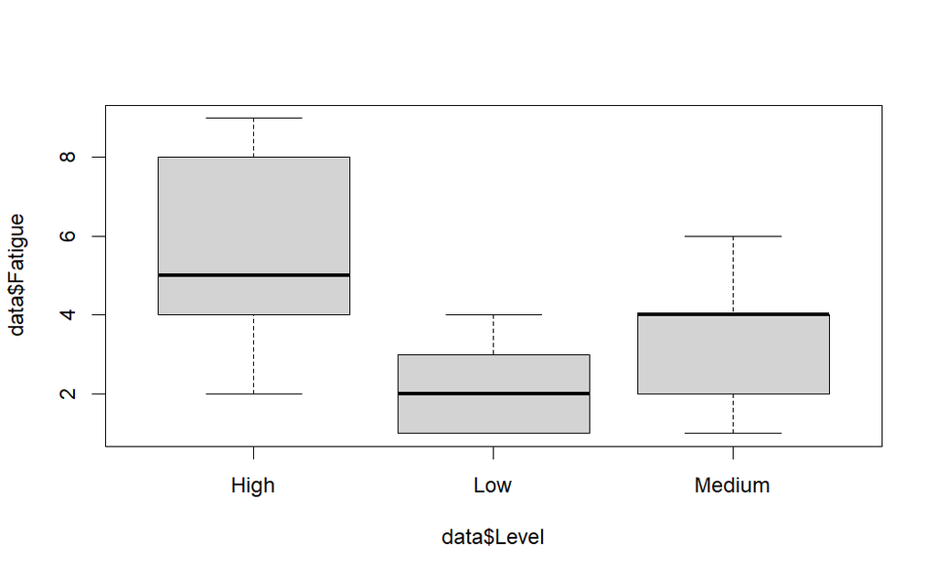

The boxplot show there is no outliers and Most of the values fall in the High range and there is a positive relation between increasing the level fatigue and increasing level of lung cancer.

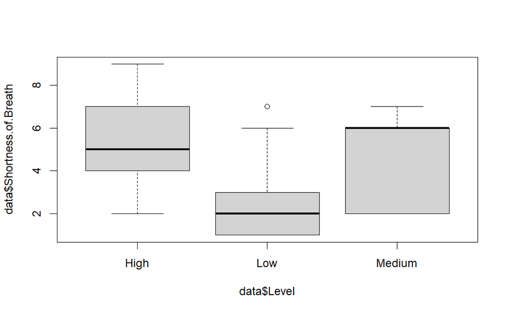

The boxplot show there is an outlier and most of the values fall in the medium range and there is a positive relation between increasing the level shortness of breath and increasing level of lung cancer.

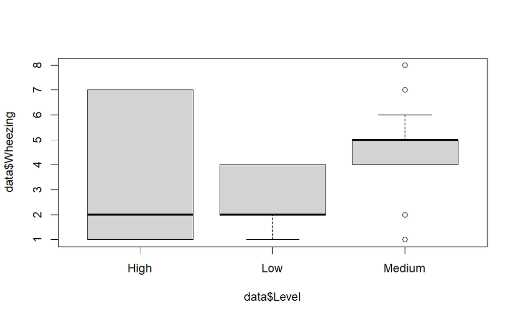

The boxplot show there is outliers and Most of the values fall in the high range and there is a relation between the level wheezing and the level of lung cancer.

```r
hist(data$Smoking)
hist(data$Alcohol.use)
hist(data$Air.Pollution)

plot(data$Dry.Cough, data$Smoking)
plot(data$Dust.Allergy, data$Chest.Pain)
plot(data$Air.Pollution, data$Chest.Pain)

boxplot(data$Air.Pollution ~ data$Level)
boxplot(data$Age)
boxplot(data$Dust.Allergy ~ data$Level)
boxplot(data$Coughing.of.Blood ~ data$Level)
boxplot(data$Fatigue ~ data$Level)
boxplot(data$Shortness.of.Breath ~ data$Level)
boxplot(data$Wheezing ~ data$Level)
```

## 4- Data preprocessing

#### Data Integration:

First, we removed the “Index” attribute since we already have the “Patient Id” attribute. We also removed the “Gender” attribute since there is a negative correlation between it and the class label.

```r
data <- data[, c(2,3,5:26)]
```

#### Detecting and removing outliers:

We identified all outliers in the “Age” attribute (TRUE represents outlier, FALSE represents non-outlier), then we remove the entire row that include any outlier.

Rinse and repeat for each attribute (except “Level” attribute).

```r
OutAge = outlier(data$Age, logical = TRUE)
sum(OutAge)
Find_outlier1 = which(OutAge == TRUE, arr.ind = TRUE)
OutAge
Find_outlier1
data = data[-Find_outlier1,]

OutAirP = outlier(data$Air.Pollution, logical = TRUE)
sum(OutAirP)
Find_outlier2 = which(OutAirP == TRUE, arr.ind = TRUE)
OutAirP
Find_outlier2
data = data[-Find_outlier2,]

OutAlcohol = outlier(data$Alcohol.use, logical = TRUE)
sum(OutAlcohol)
Find_outlier3 = which(OutAlcohol == TRUE, arr.ind = TRUE)
OutAlcohol
Find_outlier3
data = data[-Find_outlier3,]

OutDust = outlier(data$Dust.Allergy, logical = TRUE)
sum(OutDust)
Find_outlier4 = which(OutDust == TRUE, arr.ind = TRUE)
OutDust
Find_outlier4
data = data[-Find_outlier4,]

OutOccu = outlier(data$OccuPational.Hazards, logical = TRUE)
sum(OutOccu)
Find_outlier5 = which(OutOccu == TRUE, arr.ind = TRUE)
OutOccu
Find_outlier5
data = data[-Find_outlier5,]

OutGenetic = outlier(data$Genetic.Risk, logical = TRUE)
sum(OutGenetic)
Find_outlier6 = which(OutGenetic == TRUE, arr.ind = TRUE)
OutGenetic
Find_outlier6
data = data[-Find_outlier6,]

OutChroncDisease = outlier(data$chronic.Lung.Disease, logical = TRUE)
sum(OutChroncDisease)
Find_outlier7 = which(OutChroncDisease == TRUE, arr.ind = TRUE)
OutChroncDisease
Find_outlier7
data = data[-Find_outlier7,]

OutDiet = outlier(data$Balanced.Diet, logical = TRUE)
sum(OutDiet)
Find_outlier8 = which(OutDiet == TRUE, arr.ind = TRUE)
OutDiet
Find_outlier8
data = data[-Find_outlier8,]

OutObesity = outlier(data$Obesity, logical = TRUE)
sum(OutObesity)
Find_outlier9 = which(OutObesity == TRUE, arr.ind = TRUE)
OutObesity
Find_outlier9
data = data[-Find_outlier9,]

OutSmoking = outlier(data$Smoking, logical = TRUE)
sum(OutSmoking)
Find_outlier10 = which(OutSmoking == TRUE, arr.ind = TRUE)
OutSmoking
Find_outlier10
data = data[-Find_outlier10,]

OutPassiveS= outlier(data$Passive.Smoker, logical = TRUE)
sum(OutPassiveS)
Find_outlier11 = which(OutPassiveS == TRUE, arr.ind = TRUE)
OutPassiveS
Find_outlier11
data = data[-Find_outlier11,]

OutChestPain = outlier(data$Chest.Pain, logical = TRUE)
sum(OutChestPain)
Find_outlier12 = which(OutChestPain == TRUE, arr.ind = TRUE)
OutChestPain
Find_outlier12
data = data[-Find_outlier12,]

OutBloodCoughing = outlier(data$Coughing.of.Blood, logical = TRUE)
sum(OutBloodCoughing)
Find_outlier13 = which(OutBloodCoughing == TRUE, arr.ind = TRUE)
OutBloodCoughing
Find_outlier13
data = data[-Find_outlier13,]

OutFatigue = outlier(data$Fatigue, logical = TRUE)
sum(OutFatigue)
Find_outlier14 = which(OutFatigue == TRUE, arr.ind = TRUE)
OutFatigue
Find_outlier14
data = data[-Find_outlier14,]

OutWeightLoss = outlier(data$Weight.Loss, logical = TRUE)
sum(OutWeightLoss)
Find_outlier15 = which(OutWeightLoss == TRUE, arr.ind = TRUE)
OutWeightLoss
Find_outlier15
data = data[-Find_outlier15,]

OutBreathShortness = outlier(data$Shortness.of.Breath, logical = TRUE)
sum(OutBreathShortness)
Find_outlier16 = which(OutBreathShortness == TRUE, arr.ind = TRUE)
OutBreathShortness
Find_outlier16
data = data[-Find_outlier16,]

OutWheezing = outlier(data$Wheezing, logical = TRUE)
sum(OutWheezing)
Find_outlier17 = which(OutWheezing == TRUE, arr.ind = TRUE)
OutWheezing
Find_outlier17
data = data[-Find_outlier17,]

OutSwallow = outlier(data$Swallowing.Difficulty, logical = TRUE)
sum(OutSwallow)
Find_outlier18 = which(OutSwallow == TRUE, arr.ind = TRUE)
OutSwallow
Find_outlier18
data = data[-Find_outlier18,]

OutClubbing = outlier(data$Clubbing.of.Finger.Nails, logical = TRUE)
sum(OutClubbing)
Find_outlier19 = which(OutClubbing == TRUE, arr.ind = TRUE)
OutClubbing
Find_outlier19
data = data[-Find_outlier19,]

OutCold = outlier(data$Frequent.Cold, logical = TRUE)
sum(OutCold)
Find_outlier20 = which(OutCold == TRUE, arr.ind = TRUE)
OutCold
Find_outlier20
data = data[-Find_outlier20,]

OutDryCough = data(CancerSet$Dry.Cough, logical = TRUE)
sum(OutDryCough)
Find_outlier21 = which(OutDryCough == TRUE, arr.ind = TRUE)
OutDryCough
Find_outlier21
data = data[-Find_outlier21,]

OutSnoring = outlier(data$Snoring, logical = TRUE)
sum(OutSnoring)
Find_outlier22 = which(OutSnoring == TRUE, arr.ind = TRUE)
OutSnoring
Find_outlier22
data = data[-Find_outlier22,]
```

#### Data before removing the outliers:

[figure not shown]

```r
summary(data)

str(data)
```

#### Data after removing the outliers:

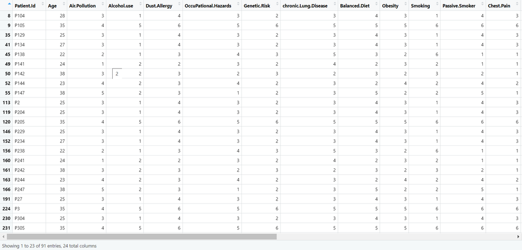

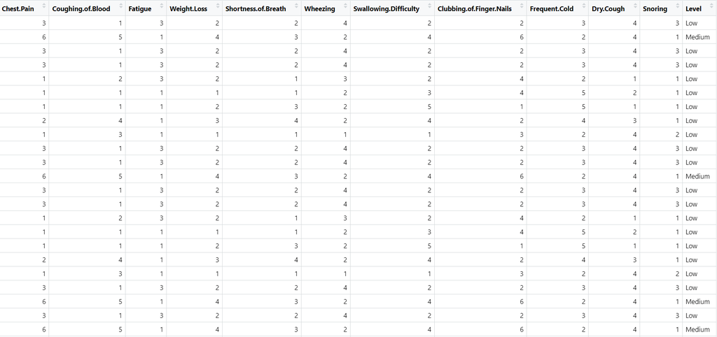

```r
summary(data)

str(data)
```

### Data transformation:

#### Encoding categorical data:

For the “Level” attribute, we can’t calculate correlation or covariance on non-numeric data, so we converted this attribute to an ordered factor, then to a numeric vector.

```r
level_factor <- factor(data$Level,  levels = c("Low","Medium","High"), ordered = TRUE)
print(level_factor)
level_factor <- as.numeric(level_factor)
```

Other than that, the data is clear, has balanced values and has no intervals that needs discretization, therefore, our data does not need any transformation.

## 5- Data mining techniques

We used both **Classification** and **Clustering** on our dataset. We used set.seed() method for each technique to make the results reproducible.

- Classification: is a supervised learning technique used to predict categorical or discrete class labels based on input features. In the context of lung cancer data analysis.

We used classification to predict the level or severity of lung cancer based on various attributes such as age, gender, genetic risk, and smoking habits. This technique included deviding the dataset into two sets: **Training set** and a **testing set**.

1. First splitting was 90% training set, and 10% testing set.
2. Second splitting was 80% training set, and 20% testing set.
3. Third splitting was 70% training set, and 30% testing set.

Calculating Information gain, gain ratio and gini index for each splitting.

Then we evaluated our models using a **Confusion Matrix,** which gave us the accuracy and cost-sensitive measures of our data.

The R packages that we used: party, partykit, RWeka,caret, rpart and rpart.plot.

The R methods that we used: createDataPartition , train , trainControl , repart.plot , ctree , plot, table , predict, confusionMatrix. These methods allowed us to split our data into two subsets, building 9 decision trees, testing prediction and evaluate our models.

- Clustering: is an unsupervised learning technique used to group similar data points together based on their intrinsic characteristics. In the context of lung cancer data analysis, clustering helped us identify subgroups of patients with similar attributes or risk factors **without the need of the class label “Level”.**

First, we selected all of our dataset’s attributes except “Patient Id” and “Level”, then we used the **K-mean** **algorithm**, which is an algorithm that produces K clusters, where each cluster is represented by the center point of the cluster and assigns each object to the nearest cluster. The algorithm iteratively recalculates the center and reassigns the object until the center point of each cluster does not change that means the object in the right cluster.

We tried 3 different K then we calculated the average silhouette width for each K. The model that has the optimal number of clusters is 5-Mean since it has no overlapping between clusters comparing to the other models.

The R packages that we used: factoextra, cluster, NbClust.

The R methods that we used: fviz_cluster , fviz_silhouette, kmeans , cat , silhouette , calculate_bcubed_metrics , fviz_nbclust.

## 6- Evaluation and Comparison

- **Classification (90% training, 10% testing):**

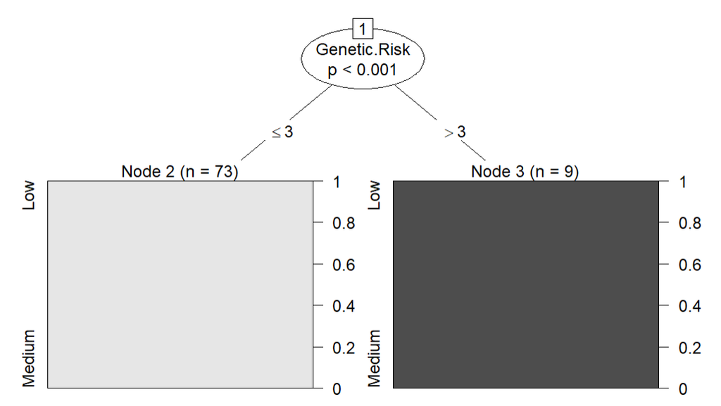

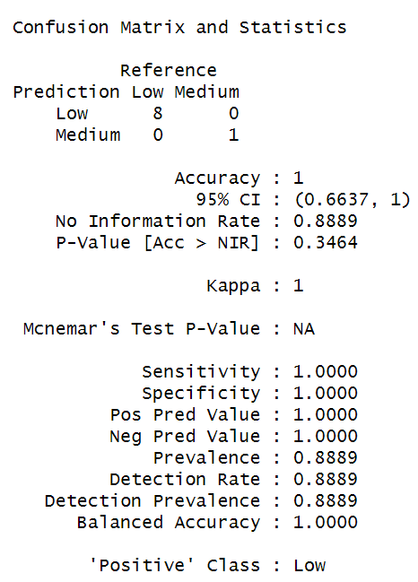

[figure not shown]

- **Classification (80% training, 20% testing):**

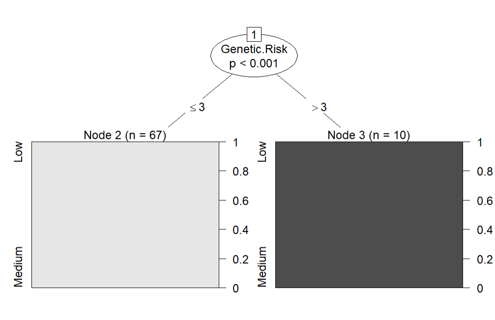

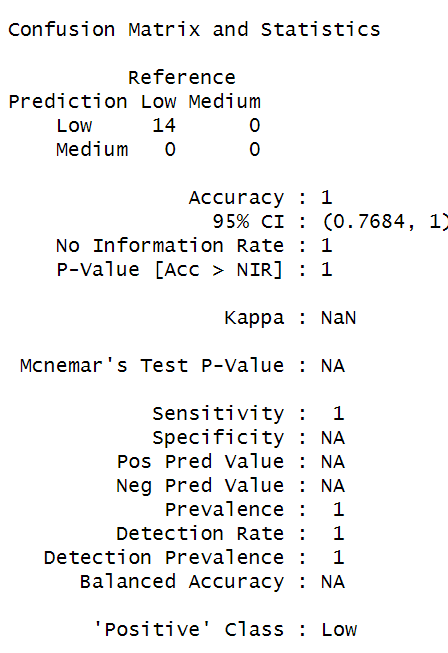

[figure not shown]

- **Classification (70% training, 30% testing):**

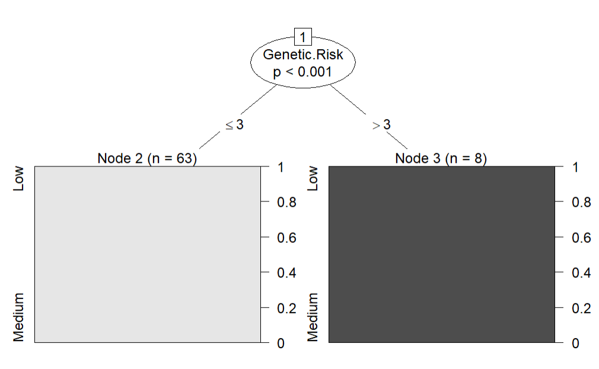

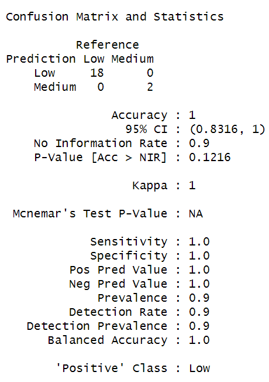

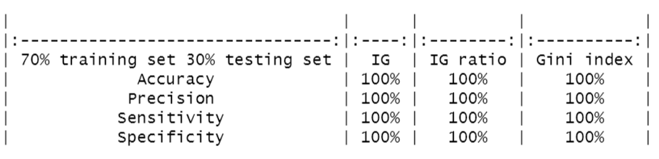

- **Clustering (K = 2):**

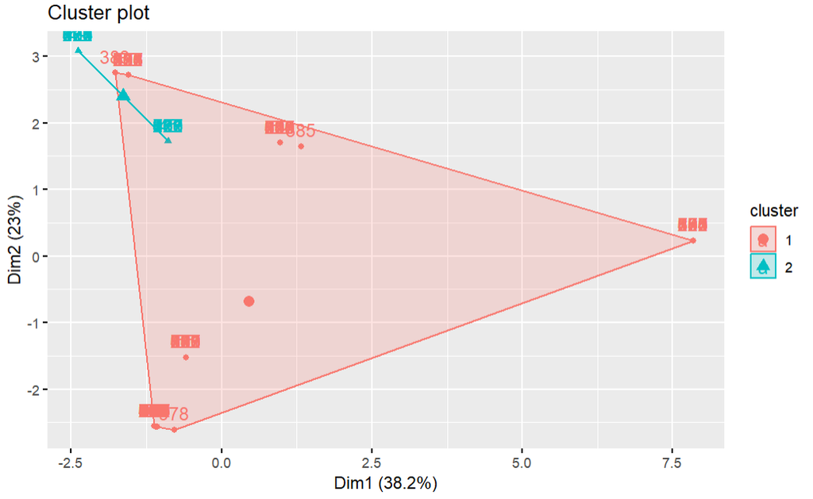

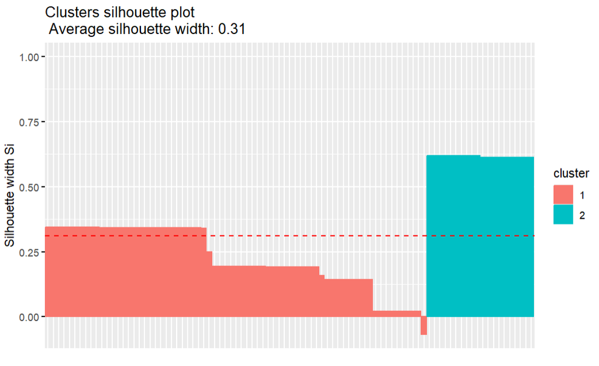

- **Clustering (K = 3):**

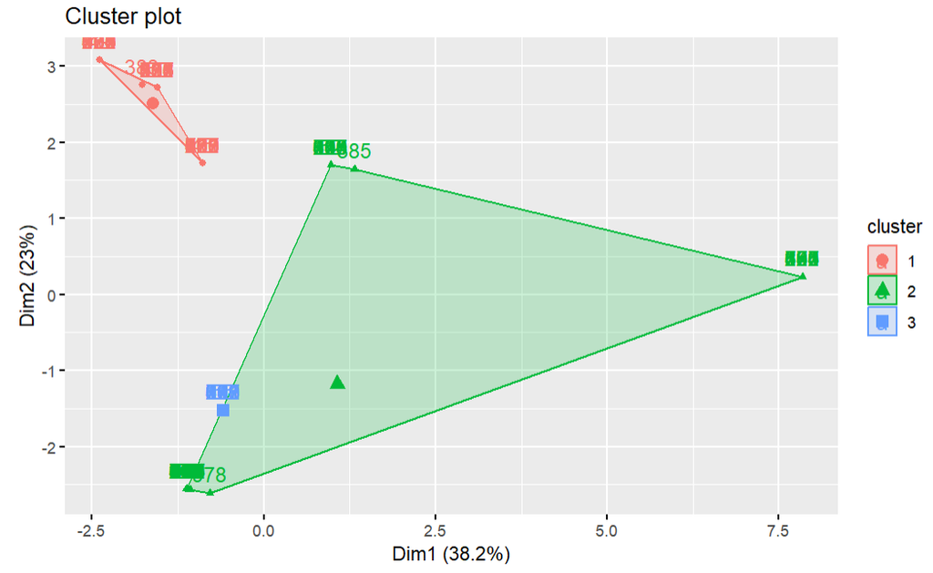

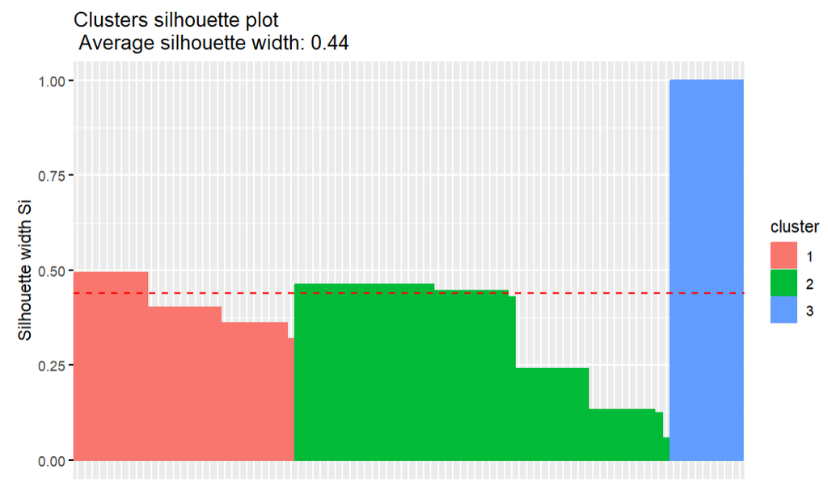

- **Clustering (K = 5):**

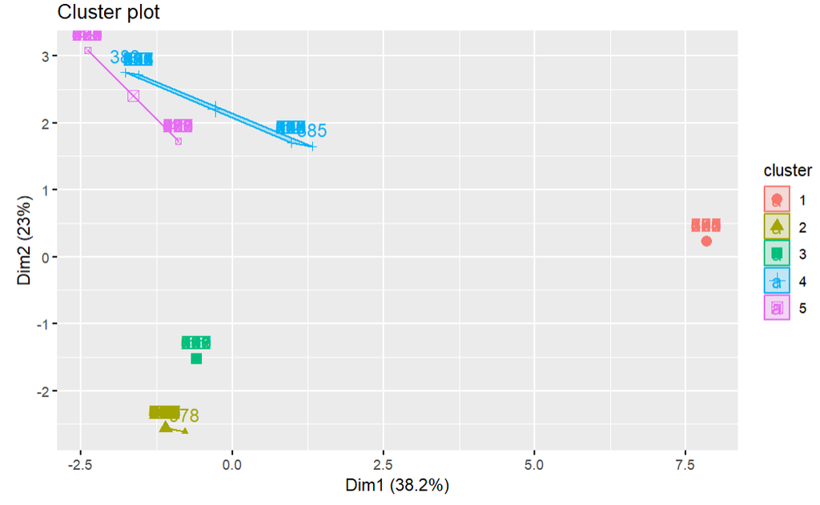

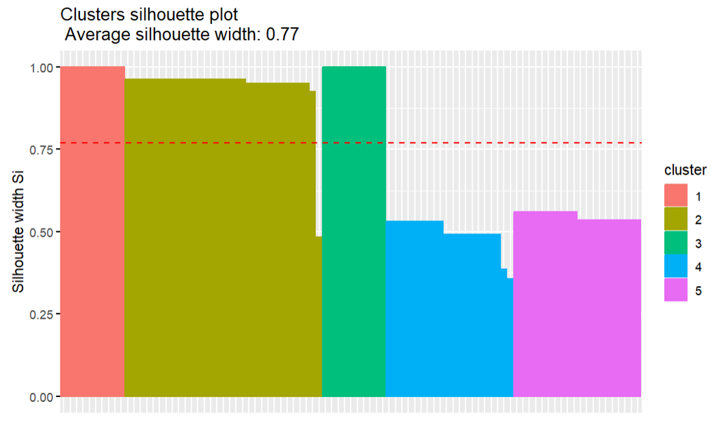

- **Optimal number of clusters:**

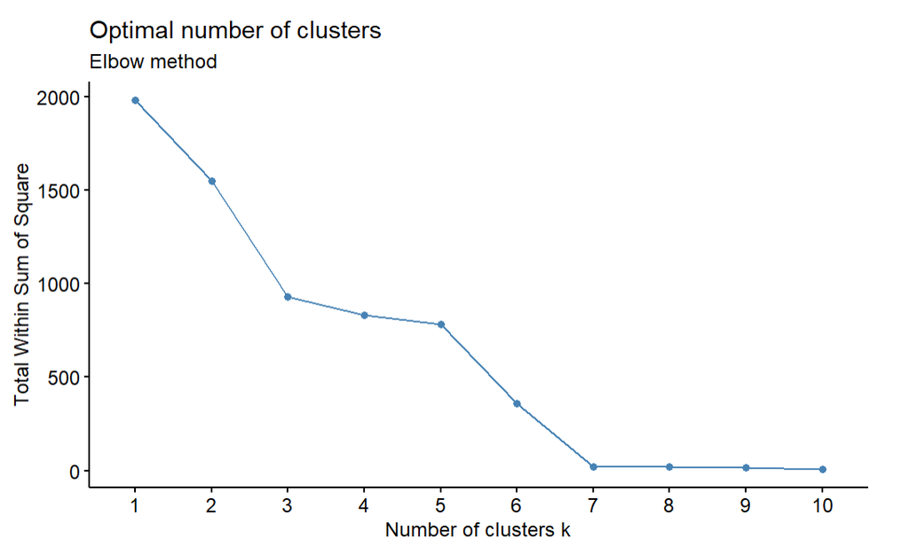

- **Clustering conclusion:**

[figure not shown]

## 7- Findings

Initially, we meticulously collected our dataset, thoroughly understanding each attribute and how its interplay with others, all in service of our primary objective. Employing diverse plotting techniques that visualized the intricate relationships between these attributes. Subsequently, our focus shifted to preprocessing and cleaning the data by removing null/missing values, redundant data, outliers, and the like. Our culminating steps involved delving into classification and clustering methodologies.

- **In Classification:**

- The 90% training data , 10% test data has a 100% accuracy.
- The 80% training data , 20% test data has a 100% accuracy.
- The 70% training data , 30% test data has a 100% accuracy.

Thus, we can use any model since all of them has the highest accuracy of 100%. We preffered using the 70/30 model.

From the 70/30 tree plot we can see that the root of our tree is the “Genetic risk” attribute, if the value of “Genetic Risk” is less than or equal to 3, the prediction of the Level of lung cancer is “Low”. If the value of “Genetic Risk” is greater than 3, the prediction of the Level of lung cancer is “Medium”.

- **In Clustering:**

- When k=2: the first silhouette is 0.22 with 71 observations , in the second the silhouette is 0.62 with 20 observations and the total number of sum square was 19.4%.

  The average of silhouette width is 0.31.
- When k=3: the first silhouette is 0.42 with 30 observations , in the second the silhouette is 0.34 with 51 observations, , in the third the silhouette is 1.00 with 10 observations and the total number of sum square was 36.4%.

  The average of silhouette width is 0.44.
- When k=5: the first silhouette is 1.00 with 10 observations , in the second the silhouette is 0.94 with 31 observations, , in the third the silhouette is 1.00 with 10 observations, in the fourth the silhouette is 0.50 with 20 observations, in the fifth the silhouette is 0.55 with 20 observations and the total number of sum square was 85.2%.

  The average of silhouette width is 0.77.

*it is more appropriate to use classification techniques rather than clustering techniques.*

Classification techniques are used when there is a known set of classes or categories, and the goal is to assign new instances to one of these predefined classes. In this project, the goal is to find the key risk factors associated with lung cancer. The dataset contains information on various attributes such as age, gender, air pollution exposure, alcohol use, and more. The ultimate objective is to analyze the dataset and identify the key risk factors associated with lung cancer. This fits the problem of classification, where the aim is to classify patients into different risk categories based on their attributes.

On the other hand, clustering techniques are used when there are no predefined classes or categories, and the goal is to discover inherent patterns or groupings in the data. Clustering algorithms would be more suitable if the objective of the project was to group patients based on similarities in their attributes, without prior knowledge of the risk factors or classes.

Therefore, in this lung cancer data mining project, the focus is on analyzing the dataset, identifying risk factors, and studying the relationship between different attributes and the occurrence of lung cancer. Classification techniques would be more appropriate for achieving these goals.